# Econometrics II - Problem 4

William Radaic Peron, Vinícius Marcial

In this problem, we’ll be forecasting GDP in the short term and creating some models of GDP growth in the long run. This presents some challenges, namely those related to *ergodicity* and *stationarity*.

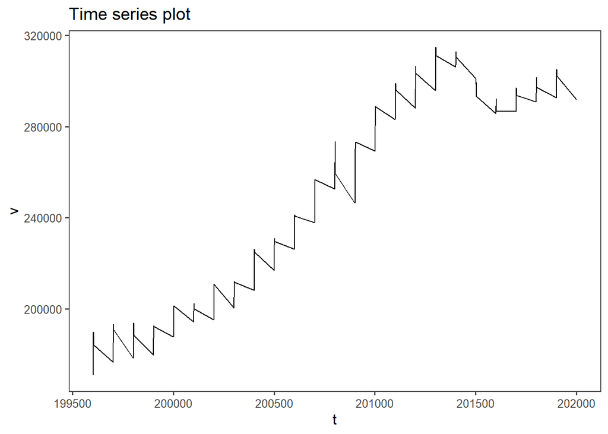

```r
pplot <- ggplot(data = pib, aes(x = t, y = v)) + geom_line() + ggtitle("Time series plot") + theme_few()
pplot
```

As we have downloaded the *pure* quarterly data, it presents *seasonality* and an upwards tendency. This implies that the *time series will not be stationary*. Therefore, we need to employ methods that circumvent this issue and assure us that we can continue modelling the series as an ARMA(p,q).

We will now assume that we can decompose the time series in three distinct elements in an additive model:
$$X_t = f_t+ s_t + Y_t$$
, where $f_t$ denotes the tendency of the ts, $s_t$ denotes seasonality, $Y_t$ is stochastic. We also assume that $f_t, s_t$ are *deterministic*.

First, we’ll construct a *parametric* model of the trend. Let’s assume that $f_t$ can be modelled by a linear form:
$$f_t = \gamma_0 + \gamma *t$$

```r
linear_trend <- lm(v ~ t, data = pib )

summary(linear_trend)
```

```
##
## Call:
## lm(formula = v ~ t, data = pib)
##
## Residuals:
##    Min     1Q Median     3Q    Max
## -34187 -11102  -1888  11332  32261
##
## Coefficients:
##               Estimate Std. Error t value Pr(>|t|)
## (Intercept) -1.225e+07  4.376e+05  -28.00   <2e-16 ***
## t            6.226e+01  2.179e+00   28.57   <2e-16 ***
## ---
## Signif. codes:  0 '***' 0.001 '**' 0.01 '*' 0.05 '.' 0.1 ' ' 1
##
## Residual standard error: 15030 on 95 degrees of freedom
## Multiple R-squared:  0.8957, Adjusted R-squared:  0.8946
## F-statistic: 816.2 on 1 and 95 DF,  p-value: < 2.2e-16
```

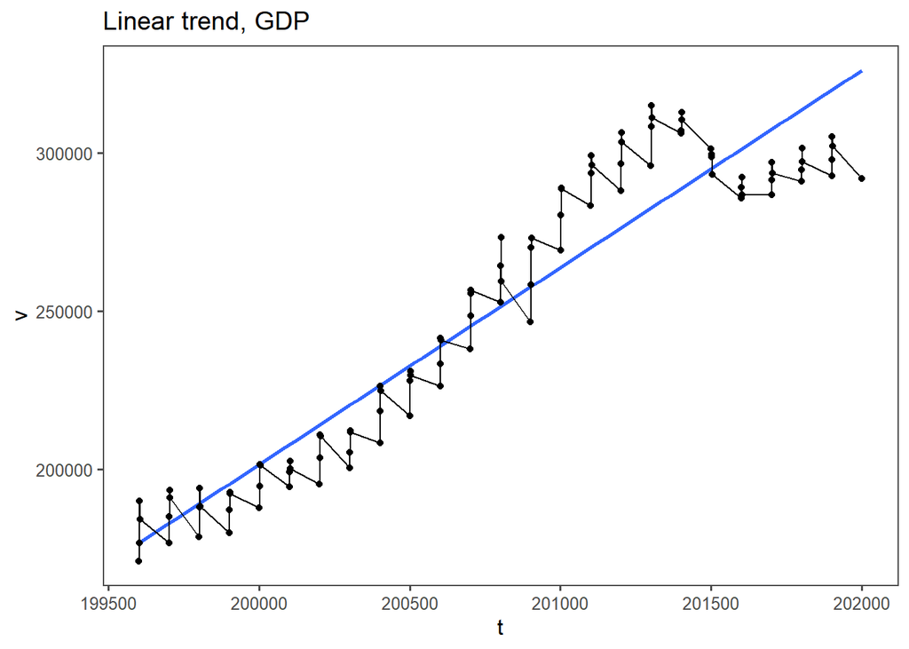

```r
ggplot(data = pib, aes(x = t, y = v)) + stat_smooth(method = "lm", se = F) + geom_line() + geom_point() + theme_few() + ggtitle("Linear trend, GDP")
```

Another way to find $f_t$ is via a *non-parametric* process. For this, we’ll use an HP filter and a moving average.

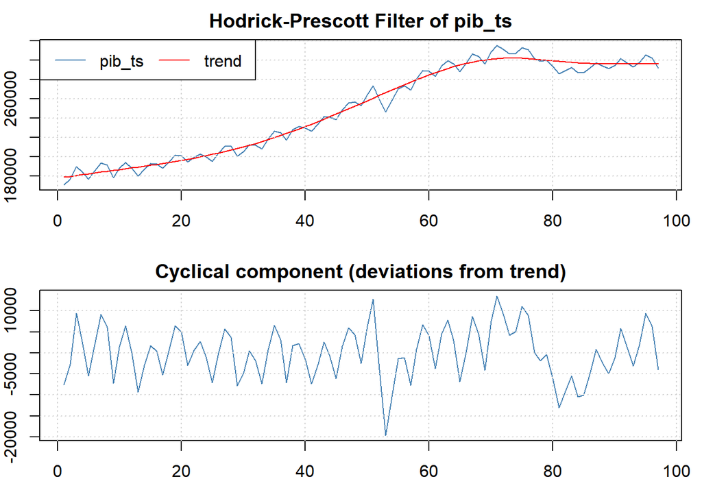

```r
pib_ts <- ts(pib$v)

hp_trend <- hpfilter(pib_ts, freq = 1600, type = "lambda")

plot(hp_trend)
```

Now, a moving average.

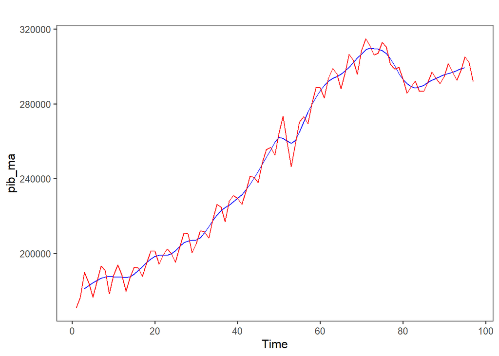

```r
pib_ma <- ma(pib$v, order = 4)

autoplot(pib_ma, color = "blue") + geom_line(data = pib, aes(x = 1:length(pib$t), y = v), color = "red") + theme_few()
```

We can now create a function for $s_t$. This will be done with dummies:
$$D_i = 1, i = t$$
$$D_i = 0 \, otherwise$$

```r
tri <- c(NA)

tri1 <- c(1,2,3,4)

i = 1

while (i < 25) {

  tri <- append(tri, tri1)

  i = i + 1

  }

tri <- tri[-1]
tri <- c(tri, 1)

tri
```

```
##  [1] 1 2 3 4 1 2 3 4 1 2 3 4 1 2 3 4 1 2 3 4 1 2 3 4 1 2 3 4 1 2 3 4 1 2 3 4 1 2
## [39] 3 4 1 2 3 4 1 2 3 4 1 2 3 4 1 2 3 4 1 2 3 4 1 2 3 4 1 2 3 4 1 2 3 4 1 2 3 4
## [77] 1 2 3 4 1 2 3 4 1 2 3 4 1 2 3 4 1 2 3 4 1
```

```r
pib <- data.frame(pib, tri)

names(pib)[1] <- "t"
names(pib)[2] <- "v"
names(pib)[3] <- "tri"

dummies <- data.frame(matrix(NA, nrow = length(pib$t), ncol = 4))

for (j in 1:4) {

  dummies[j] <- as.numeric(pib$tri == j)

}

hp_fitted <- hp_trend[2]

hp_fitted <- hp_fitted$trend

detrend <- pib$v - hp_fitted

pib <- data.frame(pib, dummies, detrend)

names(pib) <- c("t", "v", "tri", "X1", "X2", "X3", "X4", "detrend")

head(pib)
```

```
##          t        v tri X1 X2 X3 X4   detrend
## 18  199601 170920.0   1  1  0  0  0 -7639.547
## 40  199602 176708.8   2  0  1  0  0 -2784.500
## 62  199603 189844.3   3  0  0  1  0  9422.081
## 84  199604 184112.9   4  0  0  0  1  2773.122
## 106 199701 176732.2   1  1  0  0  0 -5513.291
## 128 199702 185109.5   2  0  1  0  0  1969.025
```

```r
dummy_lm <- lm(detrend ~ X2 + X3 + X4, data = pib)

summary(dummy_lm)
```

```
##
## Call:
## lm(formula = detrend ~ X2 + X3 + X4, data = pib)
##
## Residuals:
##      Min       1Q   Median       3Q      Max
## -13331.9  -2630.5    527.3   2556.1  10393.6
##
## Coefficients:
##             Estimate Std. Error t value Pr(>|t|)
## (Intercept)  -6237.1      901.3  -6.920 5.68e-10 ***
## X2            5975.6     1287.9   4.640 1.14e-05 ***
## X3           11595.9     1287.9   9.004 2.62e-14 ***
## X4            7636.9     1287.9   5.930 5.12e-08 ***
## ---
## Signif. codes:  0 '***' 0.001 '**' 0.01 '*' 0.05 '.' 0.1 ' ' 1
##
## Residual standard error: 4507 on 93 degrees of freedom
## Multiple R-squared:  0.4752, Adjusted R-squared:  0.4583
## F-statistic: 28.07 on 3 and 93 DF,  p-value: 5.155e-13
```

We’ll now use the HP-fitered version of $f_t$ and the dummy approach to $s_t$.

```r
yt <- as.vector(pib$v) - (hp_fitted + dummy_lm$fitted.values)

mean(yt)
```

```
## [1] 3.300398e-12
```

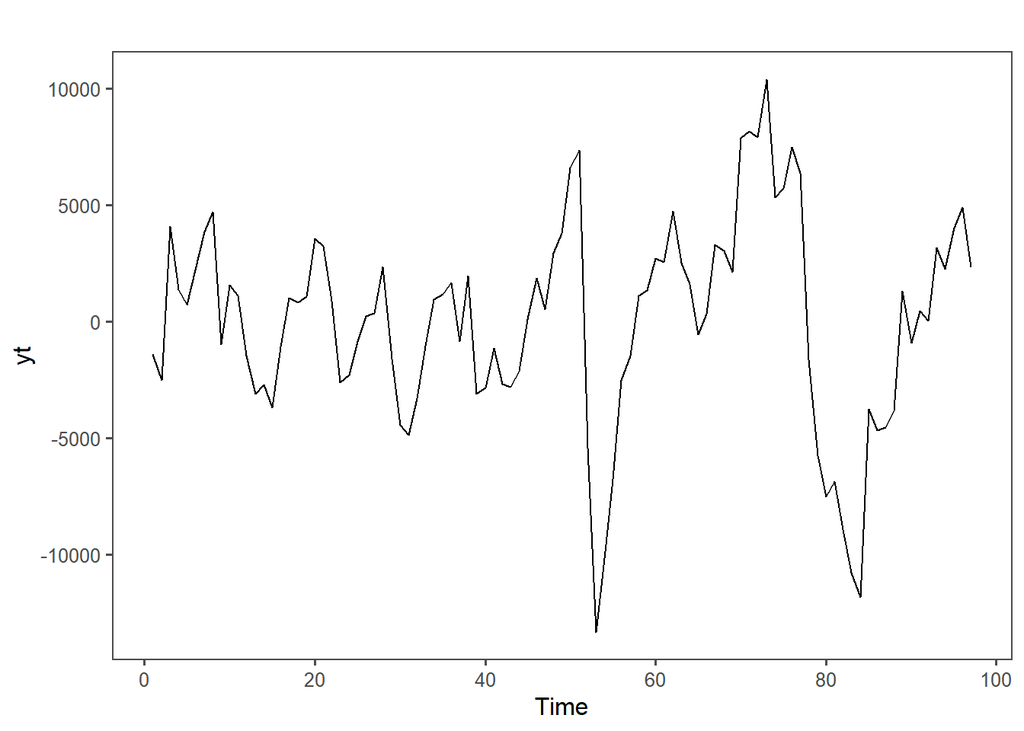

```r
autoplot(yt) + theme_few()
```

```r
y <- data.frame(1:97, yt)

names(y) <- c("t", "yt")

y
```

```
##     t           yt
## 1   1  -1402.41369
## 2   2  -2523.01651
## 3   3   4063.33233
## 4   4   1373.37256
## 5   5    723.84187
## 6   6   2230.50849
## 7   7   3863.92989
## 8   8   4706.55898
## 9   9   -997.54878
## 10 10   1561.05940
## 11 11   1109.30140
## 12 12  -1474.84104
## 13 13  -3094.32198
## 14 14  -2711.06480
```

[output cut: 83 more lines]

We are now in a position to identify and estimate the best model for our time series $Y_t$.

Applying the function *auto.arima* from the package *forecast* to identify and estimate the model:

```r
aa_model <- auto.arima(y$yt, num.cores = 24, max.d = 0, stepwise = F)

summary(aa_model)
```

```
## Series: y$yt
## ARIMA(2,0,0) with zero mean
##
## Coefficients:
##          ar1      ar2
##       0.9392  -0.2166
## s.e.  0.0984   0.0990
##
## sigma^2 estimated as 7502261:  log likelihood=-904.92
## AIC=1815.84   AICc=1816.09   BIC=1823.56
##
## Training set error measures:
##                    ME     RMSE      MAE      MPE     MAPE      MASE        ACF1
## Training set 9.709132 2710.641 2027.254 55.27169 123.3816 0.9589014 0.005486639
```

```r
print("t-values: ")
```

```
## [1] "t-values: "
```

```r
aa_t <- matrix(NA, nrow = aa_model$arma[1] + aa_model$arma[2])

for (i in c(1:(aa_model$arma[1] + aa_model$arma[2]))) {

aa_t[i] <- aa_model$coef[i]/sqrt(aa_model$var.coef[i,i])

}

aa_t <- data.frame(aa_t)

aa_t
```

```
##        aa_t
## 1  9.540429
## 2 -2.188490
```

```r
aa_q <- Box.test(aa_model$residuals, lag = aa_model$arma[1] + aa_model$arma[2])
aa_q
```

```
##
##  Box-Pierce test
##
## data:  aa_model$residuals
## X-squared = 0.0050343, df = 2, p-value = 0.9975
```

```r
criteria <- matrix(NA, nrow = 1, ncol = 3)

aa_criteria <- data.frame("AR(2)*", aa_model$aic, aa_model$bic)

names(aa_criteria) <- c("Model", "AIC", "BIC")

aa_criteria
```

```
##    Model      AIC      BIC
## 1 AR(2)* 1815.835 1823.559
```

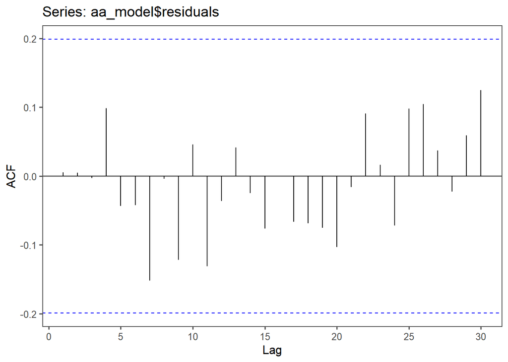

```r
fac_e <- ggAcf(aa_model$residuals, type = "correlation", lag.max = 30, plot = T) + theme_few()

facp_e <- ggPacf(aa_model$residuals, type = "correlation", lag.max = 30, plot = T) + theme_few()
fac_e
```

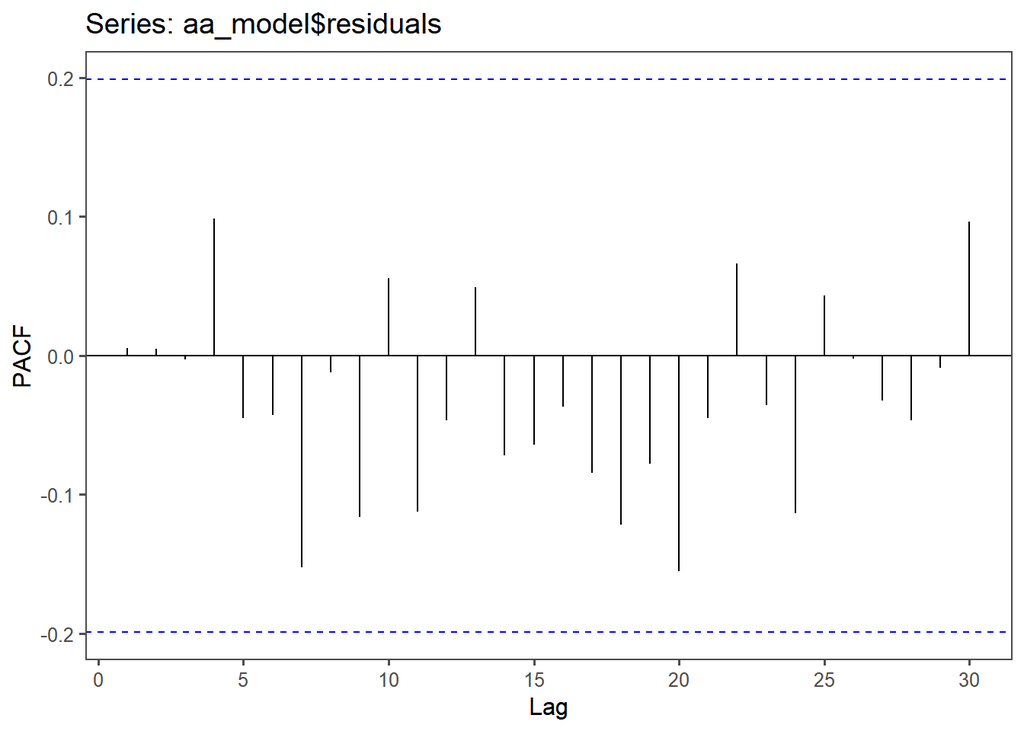

```r
facp_e
```

```r
mean(aa_model$residuals)
```

```
## [1] 9.709132
```

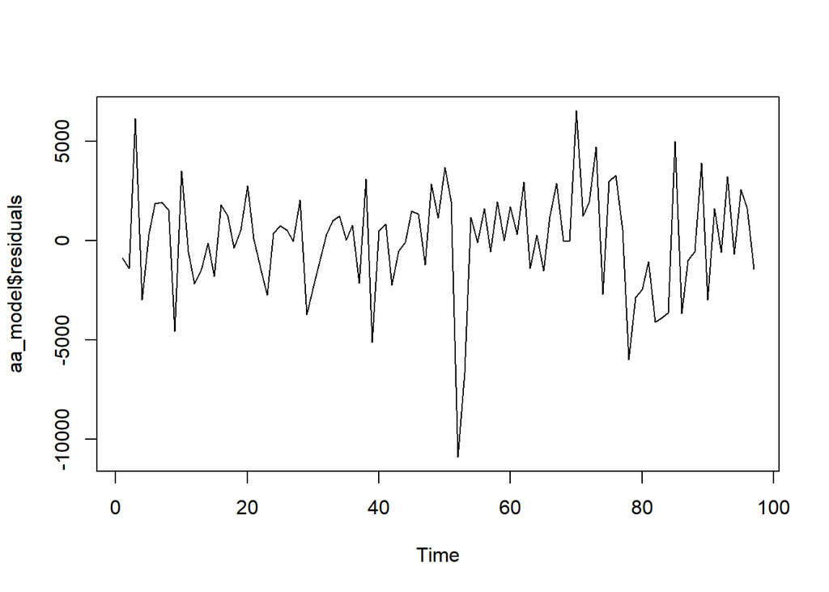

```r
plot(aa_model$residuals)
```

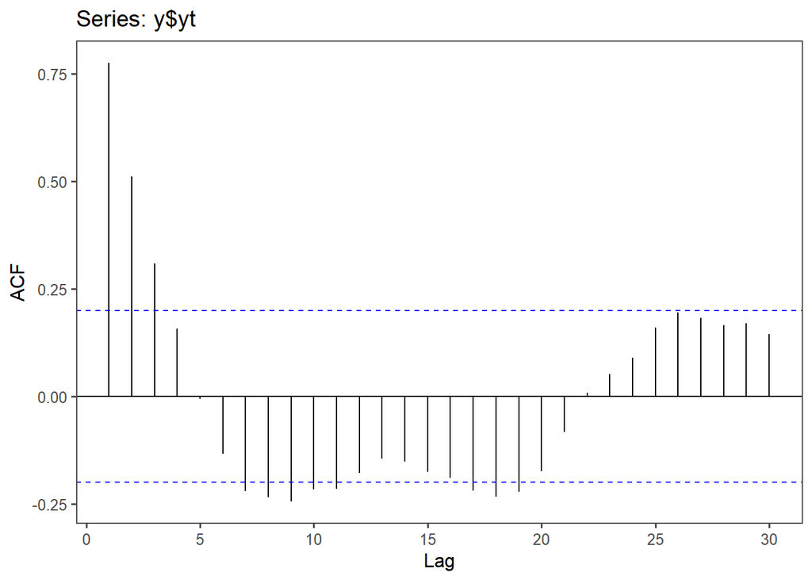

```r
facst <- ggAcf(y$yt, type = "correlation", lag.max = 30, plot = T) + theme_few()
faclt <- ggAcf(y$yt, type = "correlation", lag.max = 5000, plot = T) + theme_few()

facpst <- ggPacf(y$yt, type = "correlation", lag.max = 30, plot = T) + theme_few()
facplt <- ggPacf(y$yt, type = "correlation", lag.max = 5000, plot = T) + theme_few()
facst
```

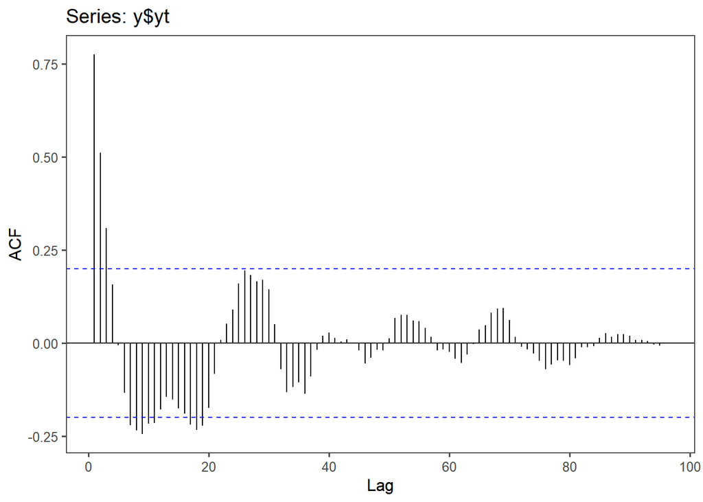

```r
faclt
```

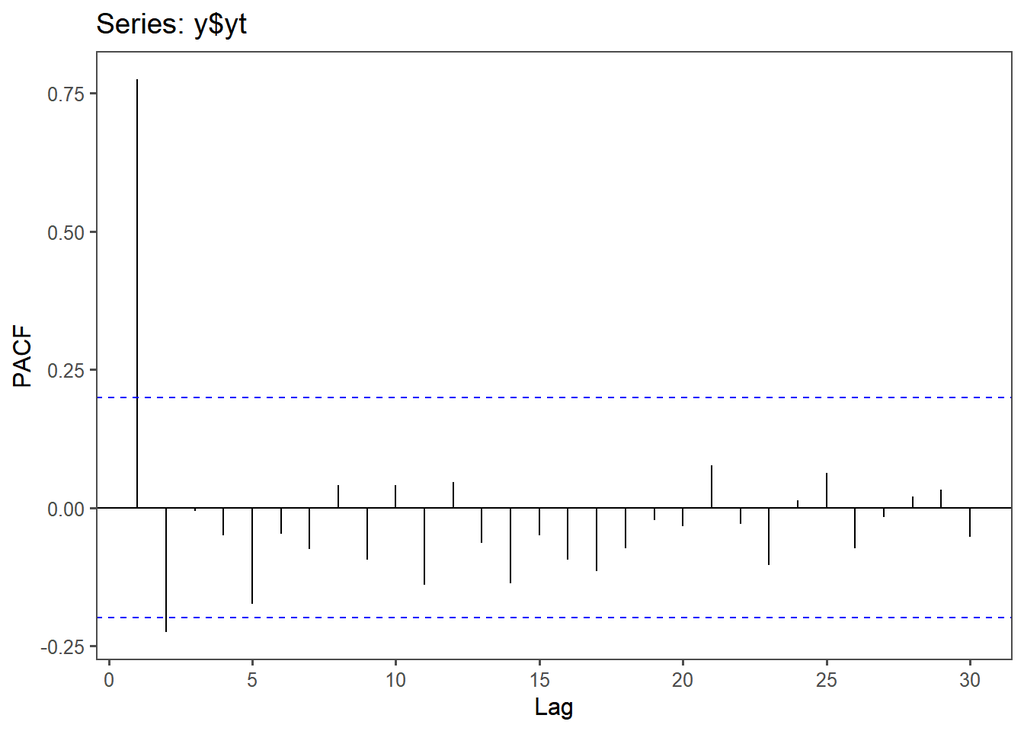

```r
facpst
```

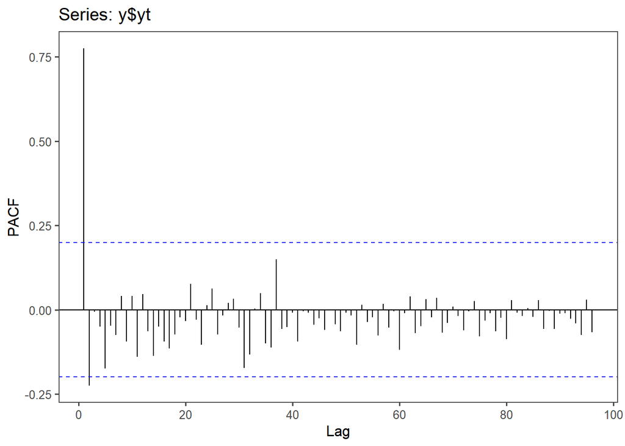

```r
facplt
```

The results of *auto.arima* imply that the best model is an ARMA(2,0) – i.e., an AR(2):
$$y_t = c + \phi_1 y_{t-1} + \phi_2 y_{t-2} + \varepsilon_t, \hspace{1em} \varepsilon_t \sim wn(0, \sigma^2)$$

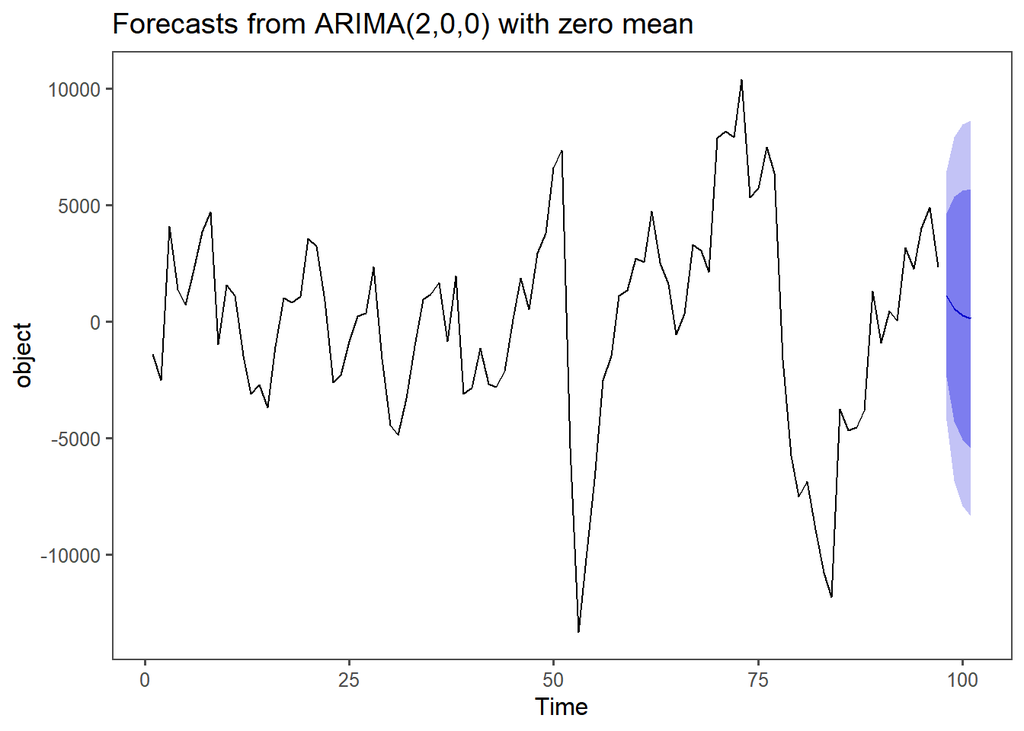

```r
fc <- forecast(y$yt, model = aa_model, h = 4)

autoplot(fc) + theme_few()
```

```r
unemp <- read_excel("C:/Users/William/Downloads/tabela2176.xlsx")
```

```
## * `` -> ...2
## * `` -> ...3
## * `` -> ...4
## * `` -> ...5
## * `` -> ...6
## * ...
```

```r
unemp1 <- as.numeric(unemp[11,])
unemp2 <- unemp1[2:(length(unemp1)-2)]

unemp <- unemp2

df_unemp <- data.frame(1:length(unemp), unemp)

names(df_unemp) <- c("t", "r")

df_unemp
```

```
##       t    r
## 1     1 12.9
## 2     2 12.5
## 3     3 11.9
## 4     4 11.6
## 5     5 11.9
## 6     6 11.7
## 7     7 11.5
## 8     8 11.2
## 9     9 10.9
## 10   10 10.5
## 11   11 11.2
## 12   12 11.6
## 13   13 12.1
## 14   14 12.4
```

[output cut: 152 more lines]

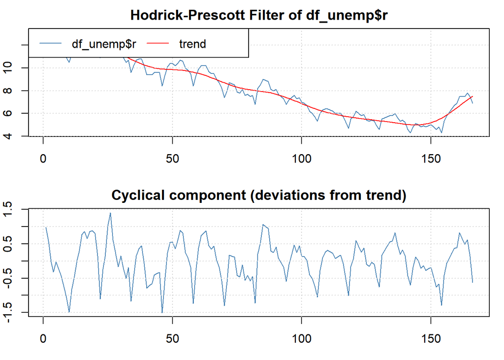

```r
hp_unemp <- hpfilter(df_unemp$r, freq = 1600, type = "lambda")

plot(hp_unemp)
```

```r
nairu <- hp_unemp$trend

nairu
```

```
##             [,1]
##   [1,] 11.927416
##   [2,] 11.924286
##   [3,] 11.921765
##   [4,] 11.920818
##   [5,] 11.922402
##   [6,] 11.927269
##   [7,] 11.936158
##   [8,] 11.949668
##   [9,] 11.968123
##  [10,] 11.991379
##  [11,] 12.018626
##  [12,] 12.048121
##  [13,] 12.077607
##  [14,] 12.104550
```

[output cut: 152 more lines]

```r
t6162 <- get_sidra(6612, variable = 9318, category = 90707, period = c("200202", "200203", "200204", "200301", "200302", "200303", "200304", "200401", "200402", "200403", "200404", "200501", "200502", "200503", "200504", "200601", "200602", "200603", "200604", "200701", "200702", "200703", "200704", "200801", "200802", "200803", "200804", "200901", "200902", "200903", "200904", "201001", "201002", "201003", "201004", "201101", "201102", "201103", "201104", "201201", "201202", "201203", "201204", "201301", "201302", "201303", "201304", "201401", "201402", "201403", "201404", "201501", "201502", "201503", "201504"))
```

```
## Considering all categories once 'classific' was set to 'all' (default)
```

```r
View(t6162)

tax <- t6162[(t6162$`Setores e subsetores (Código)` == 90706),]

tax2 <- tax[,c(5,13)]

names(tax2)[1] <- "t"
names(tax2)[2] <- "r"

tax <- tax2

trimestra <- c(NA)

i <- 0
while (i<length(unemp)){

  media <- (unemp[i] + unemp[i+1] + unemp [i+2])/3
  trimestra <- append(trimestra, media)

  i<- i +3
}

nairu_3m <- trimestra

df <- data.frame(nairu_3m[-1], tax)

df
```

```
##      nairu_3m..1.      t        r
## 17      11.800000 200202 27105.64
## 39      11.466667 200203 27761.39
## 61      10.866667 200204 27645.46
## 83      12.033333 200301 26900.42
## 105     12.900000 200302 26877.27
## 127     12.966667 200303 27423.26
## 149     11.600000 200304 27890.17
## 171     12.633333 200401 27650.37
## 193     11.700000 200402 28727.94
## 215     10.933333 200403 29776.18
## 237     10.166667 200404 29890.40
## 259     10.766667 200501 28736.12
## 281      9.666667 200502 30275.09
## 303      9.533333 200503 30877.38
```

[output cut: 41 more lines]

```r
names(df) <- c("NAIRU", "t", "tax")

growth_lm <- lm(NAIRU ~ tax, data = df)

summary(growth_lm)
```

```
##
## Call:
## lm(formula = NAIRU ~ tax, data = df)
##
## Residuals:
##     Min      1Q  Median      3Q     Max
## -1.1801 -0.3400 -0.0709  0.3167  1.6633
##
## Coefficients:
##               Estimate Std. Error t value Pr(>|t|)
## (Intercept)  2.110e+01  4.471e-01   47.19   <2e-16 ***
## tax         -3.479e-04  1.184e-05  -29.37   <2e-16 ***
## ---
## Signif. codes:  0 '***' 0.001 '**' 0.01 '*' 0.05 '.' 0.1 ' ' 1
##
## Residual standard error: 0.5991 on 52 degrees of freedom
##   (1 observation deleted due to missingness)
## Multiple R-squared:  0.9431, Adjusted R-squared:  0.942
## F-statistic: 862.5 on 1 and 52 DF,  p-value: < 2.2e-16
```

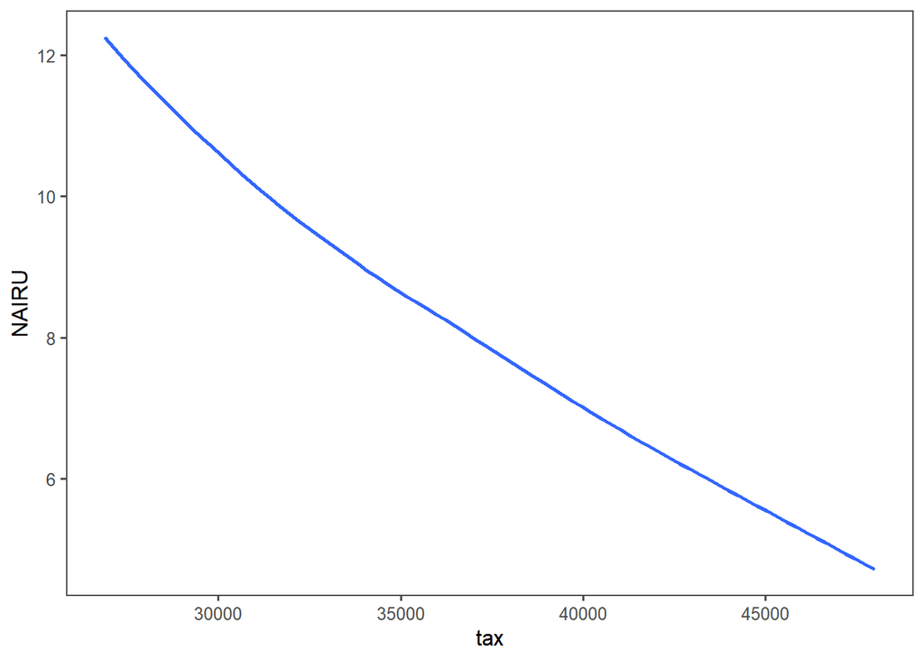

```r
ggplot(data = df, aes(x = tax, y = NAIRU)) + stat_smooth(nethod = "lm", se = F) + theme_few()
```